# DATA6075BCode

## Step 6: Display the full dataset

```r
knitr::kable(TR)
```

| Player_Name | State | Pre_Rating | Games_Played | Actual_Score | Expected_Score | Difference |
| --- | --- | --- | --- | --- | --- | --- |
| GARY HUA | ON | 1794 | 7 | 6.0 | 5.16 | 0.84 |
| DAKSHESH DARURI | MI | 1553 | 7 | 6.0 | 3.78 | 2.22 |
| ADITYA BAJAJ | MI | 1384 | 7 | 6.0 | 1.95 | 4.05 |
| PATRICK H SCHILLING | MI | 1716 | 7 | 5.5 | 4.74 | 0.76 |
| HANSHI ZUO | MI | 1655 | 7 | 5.5 | 4.38 | 1.12 |
| HANSEN SONG | OH | 1686 | 7 | 5.0 | 4.94 | 0.06 |
| GARY DEE SWATHELL | MI | 1649 | 7 | 5.0 | 4.58 | 0.42 |
| EZEKIEL HOUGHTON | MI | 1641 | 7 | 5.0 | 5.03 | -0.03 |
| STEFANO LEE | ON | 1411 | 7 | 5.0 | 2.29 | 2.71 |
| ANVIT RAO | MI | 1365 | 7 | 5.0 | 1.94 | 3.06 |
| CAMERON WILLIAM MC LEMAN | MI | 1712 | 7 | 4.5 | 5.34 | -0.84 |
| KENNETH J TACK | MI | 1663 | 6 | 4.5 | 4.11 | 0.39 |
| TORRANCE HENRY JR | MI | 1666 | 7 | 4.5 | 4.95 | -0.45 |
| BRADLEY SHAW | MI | 1610 | 7 | 4.5 | 4.18 | 0.32 |
| ZACHARY JAMES HOUGHTON | MI | 1220 | 7 | 4.5 | 1.37 | 3.13 |
| MIKE NIKITIN | MI | 1604 | 5 | 4.0 | 3.80 | 0.20 |
| RONALD GRZEGORCZYK | MI | 1629 | 7 | 4.0 | 4.66 | -0.66 |
| DAVID SUNDEEN | MI | 1600 | 7 | 4.0 | 4.59 | -0.59 |
| DIPANKAR ROY | MI | 1564 | 7 | 4.0 | 4.33 | -0.33 |
| JASON ZHENG | MI | 1595 | 7 | 4.0 | 5.13 | -1.13 |
| DINH DANG BUI | ON | 1563 | 7 | 4.0 | 4.32 | -0.32 |
| EUGENE L MCCLURE | MI | 1555 | 6 | 4.0 | 4.48 | -0.48 |
| ALAN BUI | ON | 1363 | 7 | 4.0 | 3.94 | 0.06 |
| MICHAEL R ALDRICH | MI | 1229 | 7 | 4.0 | 2.55 | 1.45 |
| LOREN SCHWIEBERT | MI | 1745 | 7 | 3.5 | 6.28 | -2.78 |
| MAX ZHU | ON | 1579 | 7 | 3.5 | 4.10 | -0.60 |
| GAURAV GIDWANI | MI | 1552 | 6 | 3.5 | 4.00 | -0.50 |
| SOFIA ADINA STANESCU-BELLU | MI | 1507 | 7 | 3.5 | 3.31 | 0.19 |
| CHIEDOZIE OKORIE | MI | 1602 | 6 | 3.5 | 4.60 | -1.10 |
| GEORGE AVERY JONES | ON | 1522 | 7 | 3.5 | 6.02 | -2.52 |
| RISHI SHETTY | MI | 1494 | 7 | 3.5 | 5.09 | -1.59 |
| JOSHUA PHILIP MATHEWS | ON | 1441 | 7 | 3.5 | 3.72 | -0.22 |
| JADE GE | MI | 1449 | 7 | 3.5 | 4.64 | -1.14 |
| MICHAEL JEFFERY THOMAS | MI | 1399 | 7 | 3.5 | 3.44 | 0.06 |
| JOSHUA DAVID LEE | MI | 1438 | 7 | 3.5 | 4.96 | -1.46 |
| SIDDHARTH JHA | MI | 1355 | 6 | 3.5 | 2.70 | 0.80 |
| AMIYATOSH PWNANANDAM | MI | 980 | 5 | 3.5 | 0.77 | 2.73 |
| BRIAN LIU | MI | 1423 | 6 | 3.0 | 2.13 | 0.87 |
| JOEL R HENDON | MI | 1436 | 7 | 3.0 | 3.62 | -0.62 |
| FOREST ZHANG | MI | 1348 | 7 | 3.0 | 2.94 | 0.06 |
| KYLE WILLIAM MURPHY | MI | 1403 | 4 | 3.0 | 2.36 | 0.64 |
| JARED GE | MI | 1332 | 7 | 3.0 | 5.01 | -2.01 |
| ROBERT GLEN VASEY | MI | 1283 | 7 | 3.0 | 4.33 | -1.33 |
| JUSTIN D SCHILLING | MI | 1199 | 6 | 3.0 | 2.07 | 0.93 |
| DEREK YAN | MI | 1242 | 7 | 3.0 | 4.37 | -1.37 |
| JACOB ALEXANDER LAVALLEY | MI | 377 | 7 | 3.0 | 0.04 | 2.96 |
| ERIC WRIGHT | MI | 1362 | 7 | 2.5 | 3.19 | -0.69 |
| DANIEL KHAIN | MI | 1382 | 5 | 2.5 | 2.53 | -0.03 |
| MICHAEL J MARTIN | MI | 1291 | 5 | 2.5 | 2.54 | -0.04 |
| SHIVAM JHA | MI | 1056 | 6 | 2.5 | 1.42 | 1.08 |
| TEJAS AYYAGARI | MI | 1011 | 7 | 2.5 | 1.03 | 1.47 |
| ETHAN GUO | MI | 935 | 7 | 2.5 | 0.30 | 2.20 |
| JOSE C YBARRA | MI | 1393 | 3 | 2.0 | 1.72 | 0.28 |
| LARRY HODGE | MI | 1270 | 6 | 2.0 | 3.40 | -1.40 |
| ALEX KONG | MI | 1186 | 6 | 2.0 | 1.44 | 0.56 |
| MARISA RICCI | MI | 1153 | 5 | 2.0 | 1.08 | 0.92 |
| MICHAEL LU | MI | 1092 | 6 | 2.0 | 1.30 | 0.70 |
| VIRAJ MOHILE | MI | 917 | 6 | 2.0 | 0.43 | 1.57 |
| SEAN M MC CORMICK | MI | 853 | 6 | 2.0 | 0.41 | 1.59 |
| JULIA SHEN | MI | 967 | 5 | 1.5 | 0.60 | 0.90 |
| JEZZEL FARKAS | ON | 955 | 7 | 1.5 | 0.97 | 0.53 |
| ASHWIN BALAJI | MI | 1530 | 1 | 1.0 | 0.88 | 0.12 |
| THOMAS JOSEPH HOSMER | MI | 1175 | 5 | 1.0 | 1.43 | -0.43 |
| BEN LI | MI | 1163 | 7 | 1.0 | 2.27 | -1.27 |

## Step 7: Top 5 over-performers and under-performers

```r
top_over  <- head(TR[order(-TR$Difference), ], 5)
top_under <- head(TR[order(TR$Difference), ], 5)

cat("Top 5 Over-performers:\n")
```

```
## Top 5 Over-performers:
```

```r
top_over
```

```
##                 Player_Name State Pre_Rating Games_Played Actual_Score
## 3              ADITYA BAJAJ    MI       1384            7          6.0
## 15   ZACHARY JAMES HOUGHTON    MI       1220            7          4.5
## 10                ANVIT RAO    MI       1365            7          5.0
## 46 JACOB ALEXANDER LAVALLEY    MI        377            7          3.0
## 37     AMIYATOSH PWNANANDAM    MI        980            5          3.5
##    Expected_Score Difference
## 3            1.95       4.05
## 15           1.37       3.13
## 10           1.94       3.06
## 46           0.04       2.96
## 37           0.77       2.73
```

```r
cat("\nTop 5 Under-performers:\n")
```

```
##
## Top 5 Under-performers:
```

```r
top_under
```

```
##           Player_Name State Pre_Rating Games_Played Actual_Score Expected_Score
## 25   LOREN SCHWIEBERT    MI       1745            7          3.5           6.28
## 30 GEORGE AVERY JONES    ON       1522            7          3.5           6.02
## 42           JARED GE    MI       1332            7          3.0           5.01
## 31       RISHI SHETTY    MI       1494            7          3.5           5.09
## 35   JOSHUA DAVID LEE    MI       1438            7          3.5           4.96
##    Difference
## 25      -2.78
## 30      -2.52
## 42      -2.01
## 31      -1.59
## 35      -1.46
```

## Graph 1: Actual vs. Expected Score (all players)

Points above the red dashed line (y = x) over-performed relative to their rating; points below under-performed.

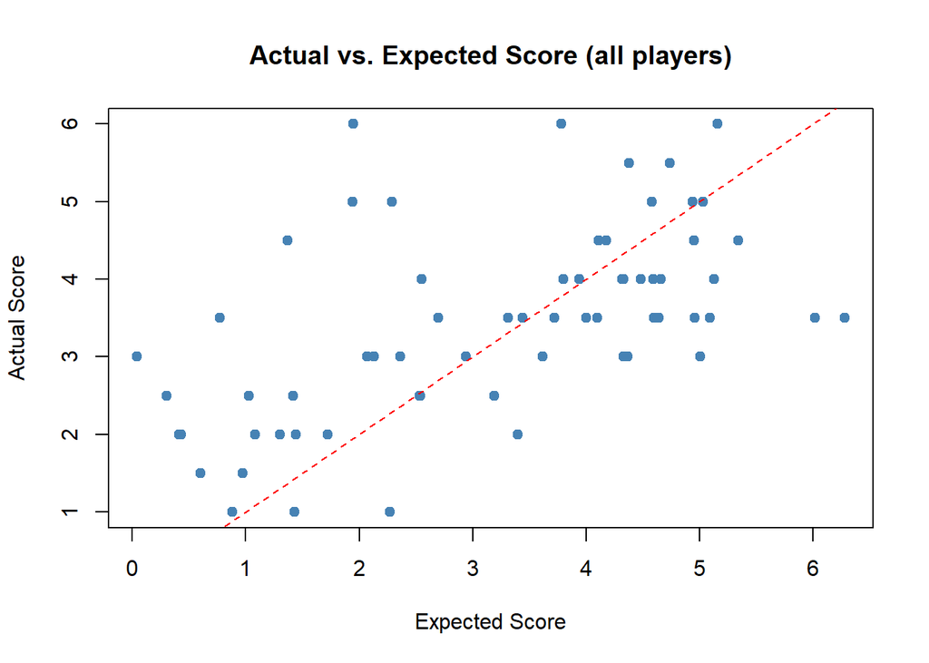

```r
plot(TR$Expected_Score, TR$Actual_Score,
     xlab = "Expected Score", ylab = "Actual Score",
     main = "Actual vs. Expected Score (all players)",
     pch = 19, col = "steelblue")
abline(a = 0, b = 1, col = "red", lty = 2)
```

## Graph 2: Top 5 Over- and Under-performers

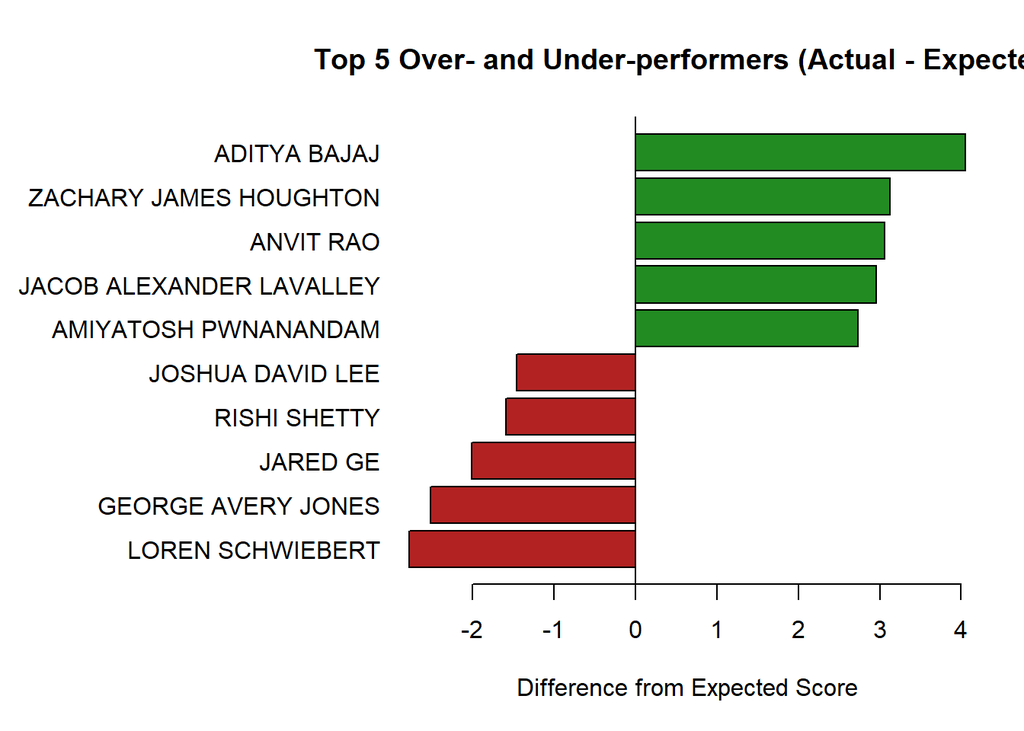

```r
combined <- rbind(top_over, top_under)
combined <- combined[order(combined$Difference), ]

par(mar = c(5, 14, 4, 2))
barplot(combined$Difference, names.arg = combined$Player_Name, horiz = TRUE, las = 1,
        col = ifelse(combined$Difference > 0, "forestgreen", "firebrick"),
        main = "Top 5 Over- and Under-performers (Actual - Expected)",
        xlab = "Difference from Expected Score")
abline(v = 0)
```

## Conclusion

The scatter plot shows that while most players performed reasonably close to their Elo-predicted expectation, a handful of players (notably lower-rated players like Aditya Bajaj and Anvit Rao) substantially exceeded their expected score, while some higher-rated players (like Loren Schwiebert) scored well below what their pre-tournament rating predicted. This is exactly the kind of signal the Elo system is designed to produce: rating changes after the tournament should push over-performers’ ratings up and under-performers’ ratings down.